# Session 4 - Answers

Callin Switzer

Oct 5, 2015

#### Topics:

- Visualization using ggplot()
  - coloring data based on a variable
  - reordering the bars or boxes in a plot
  - adding lines from loess or linear models to scatterplots
- Loops and apply functions()
- ** Writing your own functions

**if time

```
## [1] "Last knit to html at:  2015-10-06 18:21:58"
```

# Review

#### What we learned last time:

1. Navigate your data frames, using square-bracket and “$” notation.
2. Use logical statements to subset and clean data.
3. Exporting data
4. Formatting data for ggplot
5. Changing ggplot themes

Exercises(0):

### 0.1 Set your working directory to the Session4 folder.

### 0.2 Import the “CallinPollen.csv” dataset, and call it “flr”.

### 0.3 Make sure the “ggplot2” and “grid” libraries is loaded with e.g. “library(ggplot2)”. If you’re having trouble, use “install.packages(”ggplot2“)” before loading the library.

### 0.4 Use ggplot to plot a scatterplot like this:

```
 ggplot(flr, aes(x = shakeNumber, y = slope)) +
      geom_point() +
      theme_bw()
```

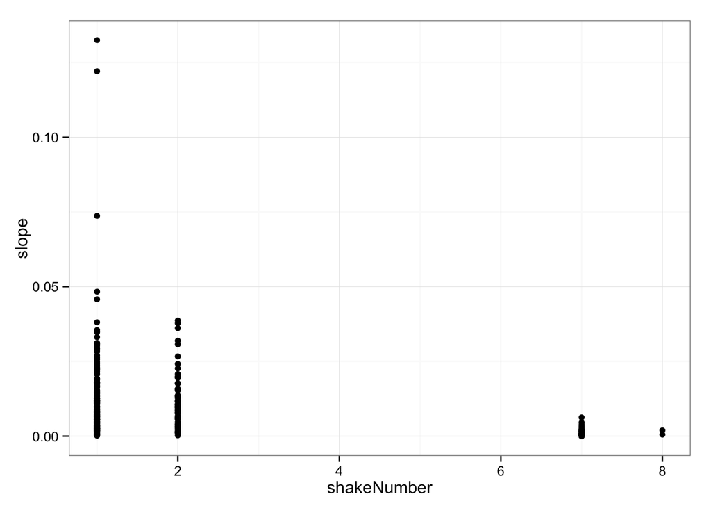

```r
# 0.1
setwd("/Users/callinswitzer/Dropbox/Harvard/RByCall/RClassMaterials/Session4")

# 0.2
library(ggplot2)
library(grid) # we need this for the "unit" function

# 0.3
flr <- read.csv("Datasets/CallinPollen.csv")

# 0.4
p1 <- ggplot(flr, aes(x = shakeNumber, y = slope)) +
     geom_point() +
     theme_bw()
p1
```

# 1. Visualization with ggplot

## Coloring / shaping points based on a factor

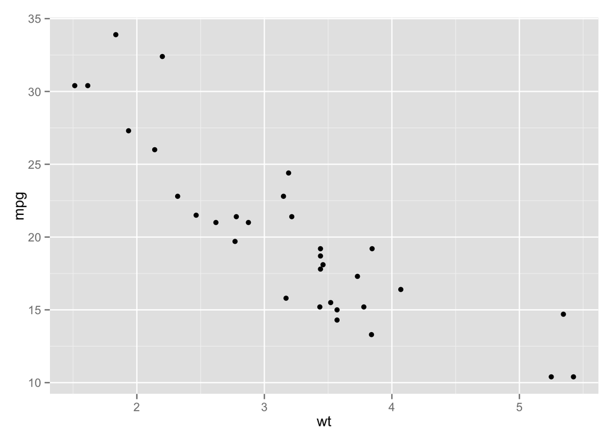

```r
# read in data
crs <- read.csv("Datasets/mtcars.txt", sep = " ")

# plot it
ggplot(crs, aes(x = wt, y = mpg)) +
     geom_point()
```

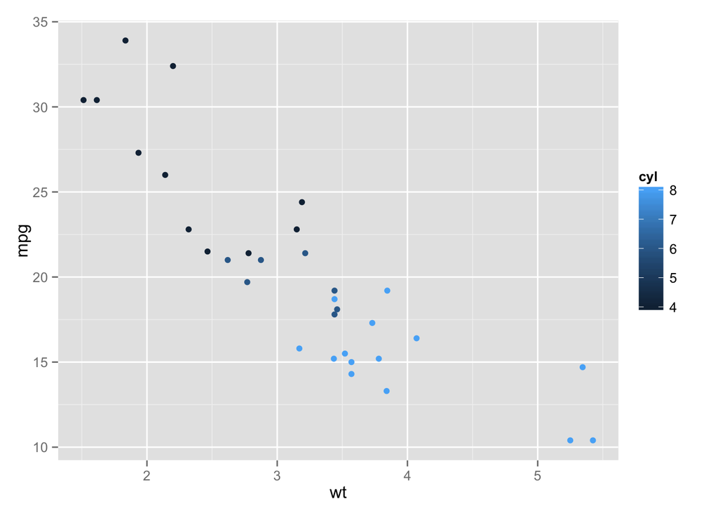

```r
# color points, based on the number of cylinders
ggplot(crs, aes(x = wt, y = mpg)) +
     geom_point(aes(color = cyl))
```

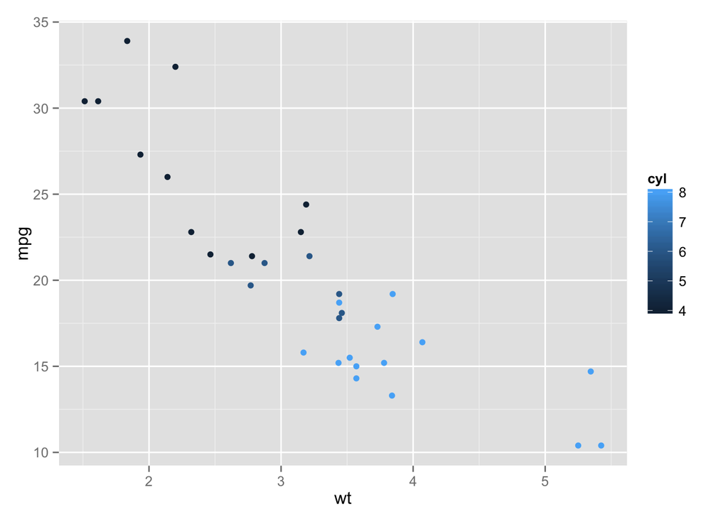

```r
# same thing
ggplot(crs, aes(x = wt, y = mpg, color = cyl)) +
     geom_point()
```

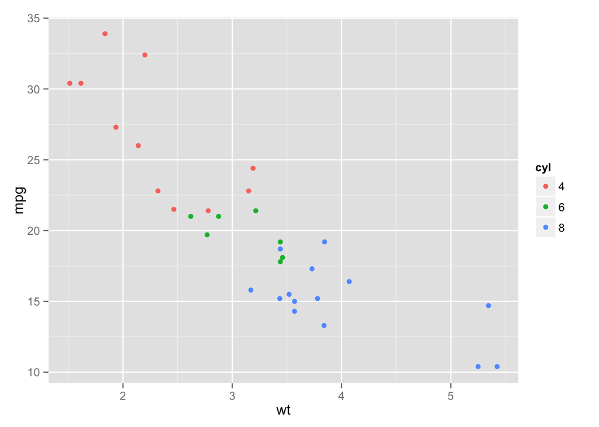

```r
# we don't want a spectrum of colors, so we'll make crs$cyl into a factor
crs$cyl <- as.factor(crs$cyl)

ggplot(crs, aes(x = wt, y = mpg)) +
     geom_point(aes(color = cyl))
```

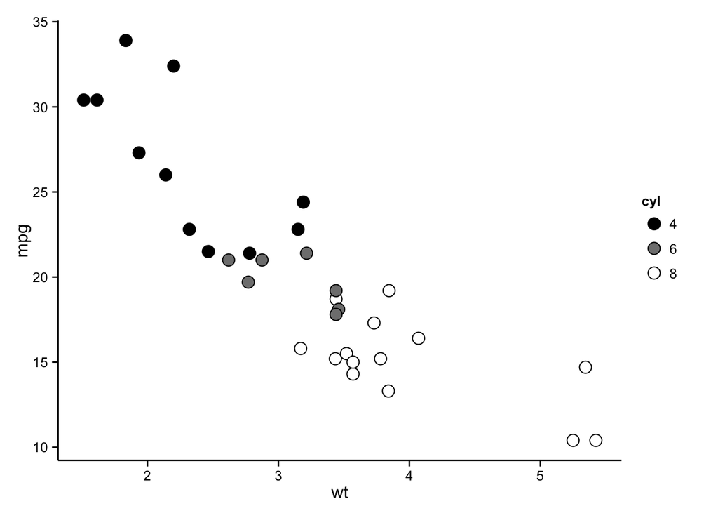

```r
# change color scheme
ggplot(crs, aes(x = wt, y = mpg)) +
     geom_point(aes(fill= cyl), color = "black",  shape = 21, size = 4) +
     theme_classic() +
     scale_fill_manual(values = c("black", "grey50", "white"))
```

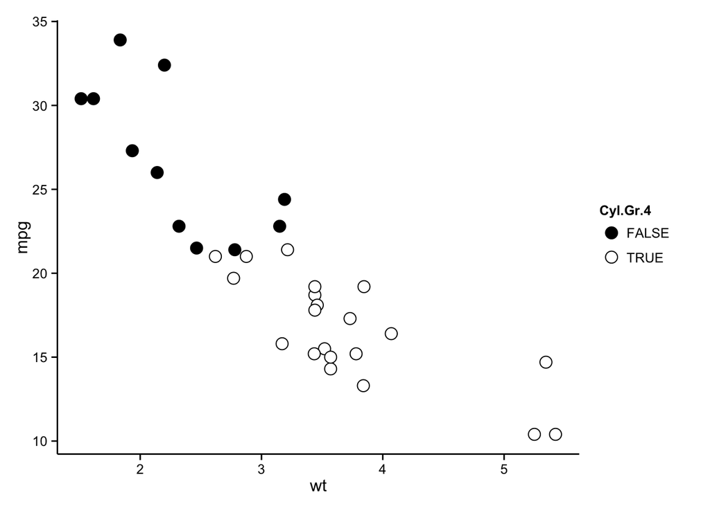

```r
# color points, based the cyl being greater than 4
Cyl.Gr.4 <- as.numeric(as.character(crs$cyl)) > 4
ggplot(crs, aes(x = wt, y = mpg)) +
     geom_point(aes(fill= Cyl.Gr.4), color = "black",  shape = 21, size = 4) +
     theme_classic() +
     scale_fill_manual(values = c("black", "white"))
```

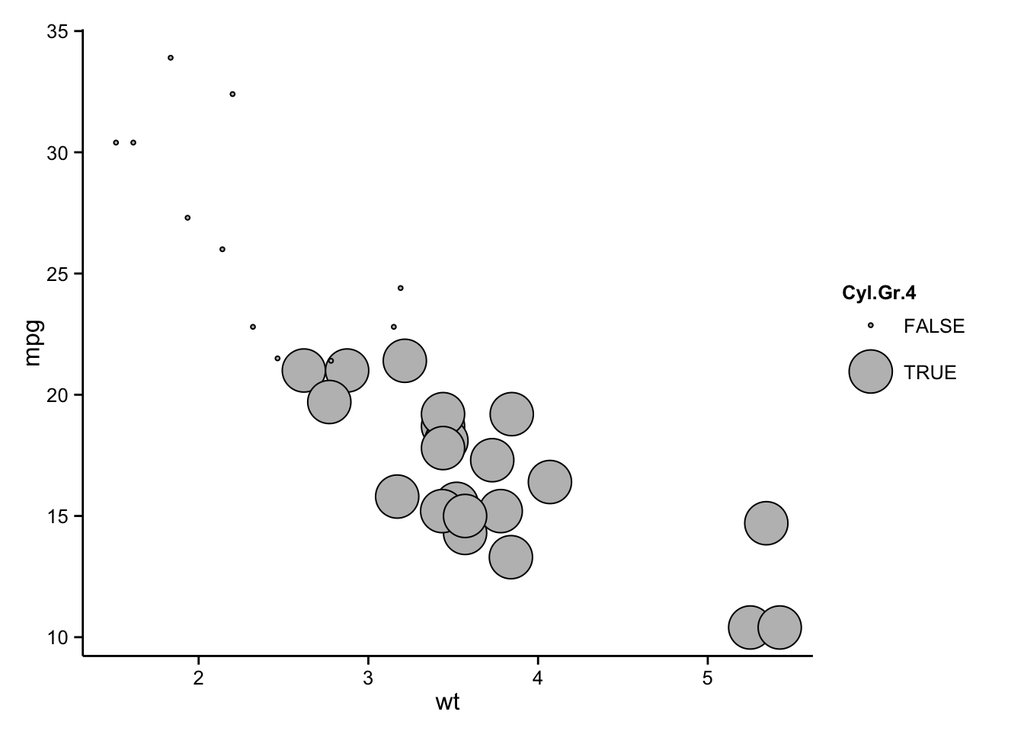

```r
# size points, based on a factor
ggplot(crs, aes(x = wt, y = mpg)) +
     geom_point(aes(size = Cyl.Gr.4), color = "black", fill = "grey",  shape = 21) +
     theme_classic() +
     scale_size_manual(values = c(1, 10))
```

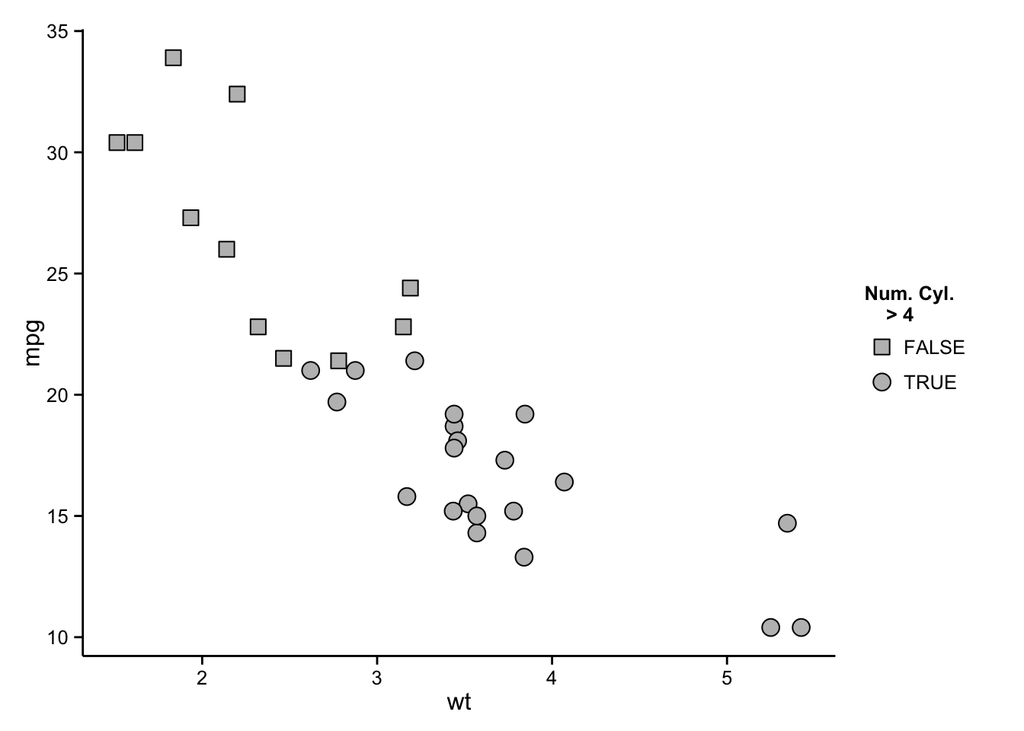

```r
# you can do the same thing with shape
ggplot(crs, aes(x = wt, y = mpg)) +
     geom_point(aes(shape = Cyl.Gr.4), color = "black", fill = "grey", size = 4) +
     theme_classic() +
     scale_shape_manual(values = c(22, 21), name = "Num. Cyl. \n    > 4")
```

Exercises(1):

#### 1.1 With the cars dataset, use ggplot to make a scatterplot of x = disp, y = mpg. Color the points differently, based on the “am” column (automatic transmission). Make sure that “am” is a factor or logical. Feel free to change the size, theme, etc.

### Making boxplots

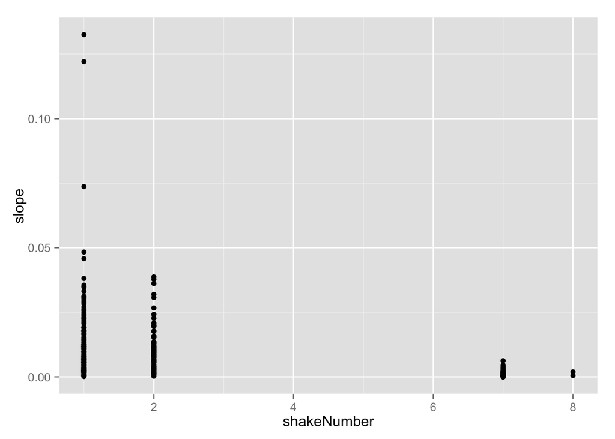

```r
################################  EXAMPLE 1 ################################
# making a boxplot
################################  EXAMPLE 1 ################################

# here's a plot that looks weird as points
ggplot(flr, aes(x = shakeNumber, y = slope)) +
     geom_point()
```

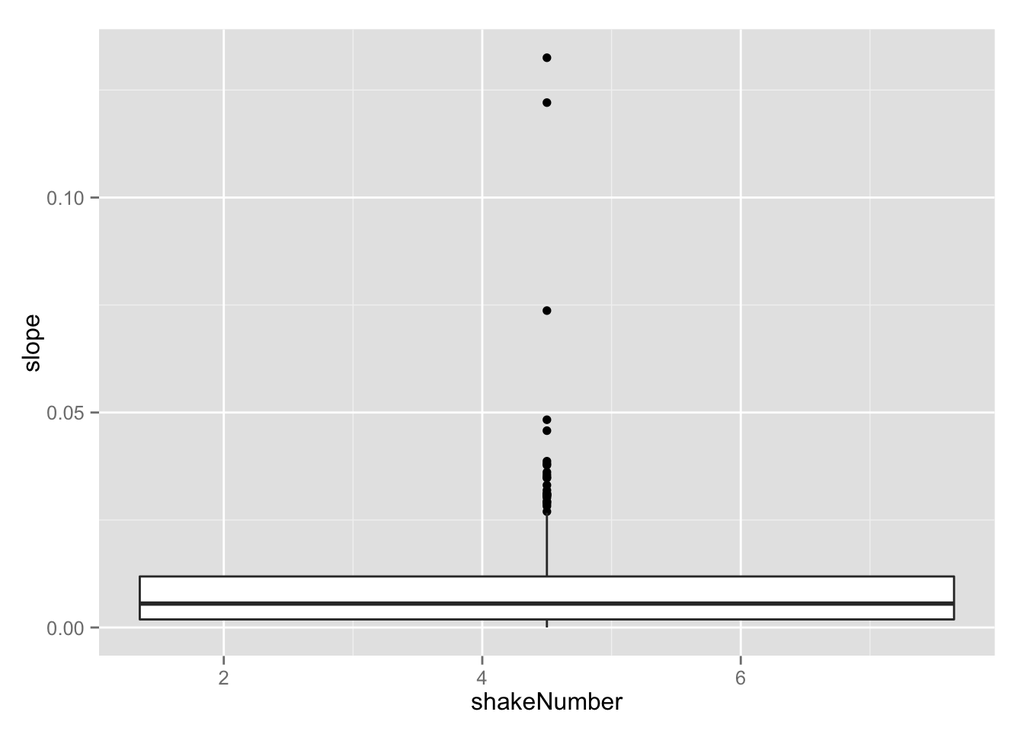

```r
# say we think that shake number should be represented with a boxplot, rather than with dots
p2 <- ggplot(flr, aes(x = shakeNumber, y = slope)) +
     geom_boxplot()
p2 # not quite right
```

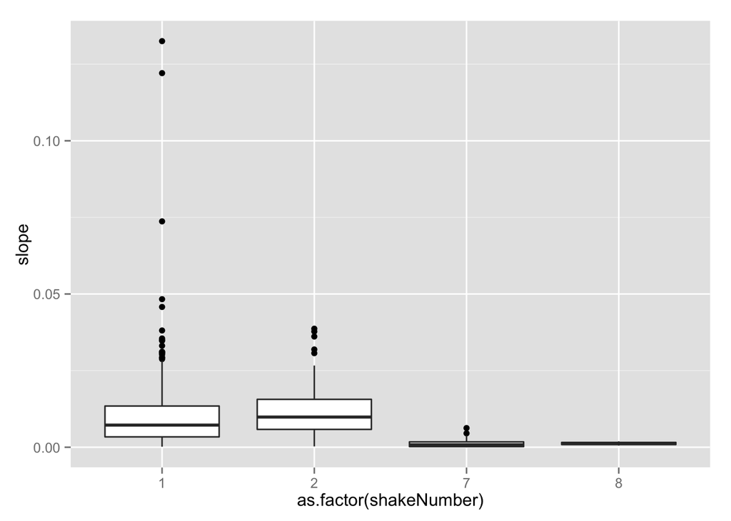

```r
p3 <- ggplot(flr, aes(x = as.factor(shakeNumber), y = slope)) +
     geom_boxplot()
p3 # much better
```

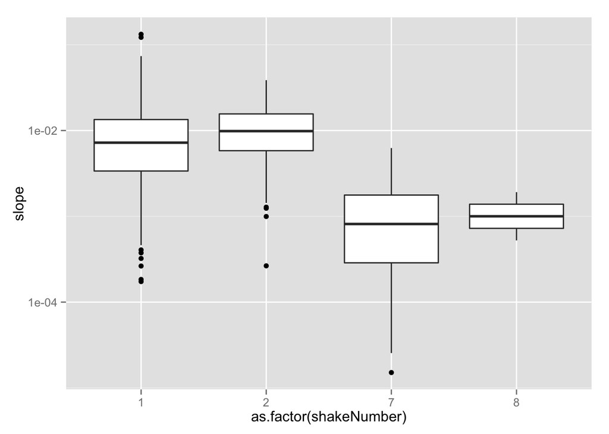

```r
# log transform
p3 + scale_y_log10()
```

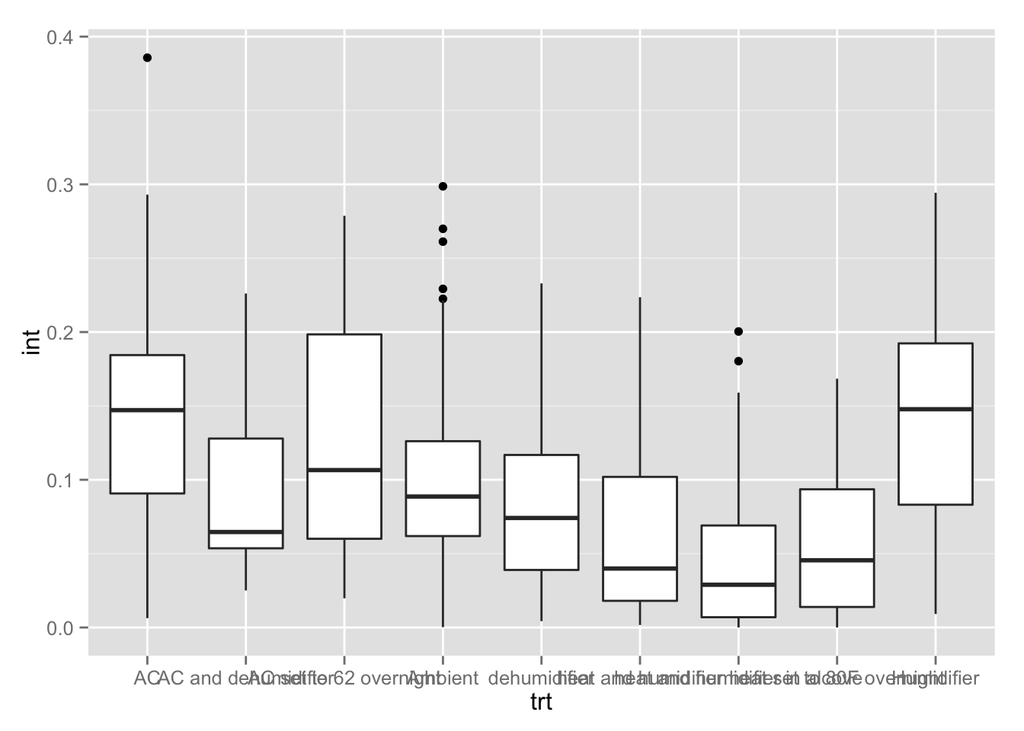

```r
################################  EXAMPLE 2 ################################
# changing the order of the boxes in a plot
################################  EXAMPLE 2 ################################

# a basic boxplot
p4 <- ggplot(flr, aes(x = trt, y = int)) +
     geom_boxplot()
p4
```

```r
# changing order of the boxes -- change levels of a factor
str(flr$trt) # factor with levels alphabetized
```

```
##  Factor w/ 9 levels "AC","AC and dehumidifier",..: 4 4 4 4 4 4 4 4 4 4 ...
```

```r
# we can change the order of the factor levels to change the plot
levels(flr$trt)
```

```
## [1] "AC"                            "AC and dehumidifier"
## [3] "AC set to 62 overnight"        "Ambient"
## [5] "dehumidifier"                  "heat and humidifier"
## [7] "heat and humidifier in alcove" "heat set to 80F overnight"
## [9] "Humidifier"
```

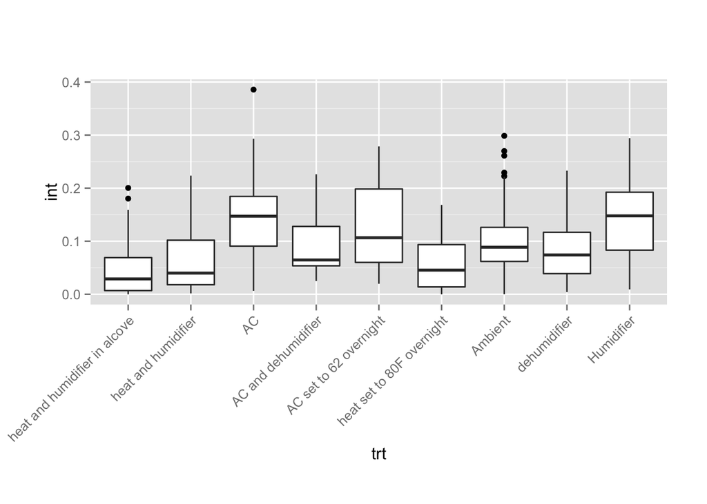

```r
newlevels <- c('heat and humidifier in alcove', 'heat and humidifier', 'AC', 'AC and dehumidifier', 'AC set to 62 overnight', 'heat set to 80F overnight', 'Ambient', 'dehumidifier', 'Humidifier')
flr$trt <- factor(flr$trt, levels =  newlevels)

p5 <- ggplot(flr, aes(x = trt, y = int)) +
     geom_boxplot() +
     theme(axis.text.x = element_text(angle = 45, hjust = 1), # make text 45 degrees
           plot.margin = unit(c(2,1,1,1), "cm")) # move the left margin over
p5
```

```r
# we can order the factor levels based on their means
(trtMeans <- tapply(X = flr$int, FUN = mean, INDEX = flr$trt))
```

```
## heat and humidifier in alcove           heat and humidifier
##                    0.05134368                    0.06338917
##                            AC           AC and dehumidifier
##                    0.14195595                    0.09301399
##        AC set to 62 overnight     heat set to 80F overnight
##                    0.12963241                    0.05722544
##                       Ambient                  dehumidifier
##                    0.09773810                    0.08195999
##                    Humidifier
##                    0.14091004
```

```r
# sort the treatments
(trtMeans.sort <- trtMeans[order(trtMeans, decreasing = TRUE)])
```

```
##                            AC                    Humidifier
##                    0.14195595                    0.14091004
##        AC set to 62 overnight                       Ambient
##                    0.12963241                    0.09773810
##           AC and dehumidifier                  dehumidifier
##                    0.09301399                    0.08195999
##           heat and humidifier     heat set to 80F overnight
##                    0.06338917                    0.05722544
## heat and humidifier in alcove
##                    0.05134368
```

```r
names(trtMeans.sort) # sorted vector, based on mean
```

```
## [1] "AC"                            "Humidifier"
## [3] "AC set to 62 overnight"        "Ambient"
## [5] "AC and dehumidifier"           "dehumidifier"
## [7] "heat and humidifier"           "heat set to 80F overnight"
## [9] "heat and humidifier in alcove"
```

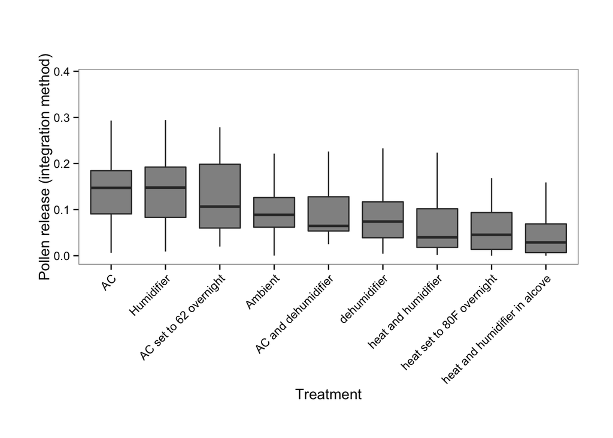

```r
# change the factor levels
flr$trt <- factor(flr$trt, levels = names(trtMeans.sort))

p6.ordered <- ggplot(flr, aes(x = trt, y = int)) +
     geom_boxplot(fill = 'black', alpha = 0.5, outlier.colour = NA) + # don't show outliers
     theme_bw() +
     theme(axis.text.x = element_text(angle = 45, hjust = 1),
           panel.grid.major = element_blank(),
           panel.grid.minor = element_blank(),
           plot.margin = unit(c(2,1,1,1), "cm")) +
     labs(x = "Treatment", y = "Pollen release (integration method)")

p6.ordered
```

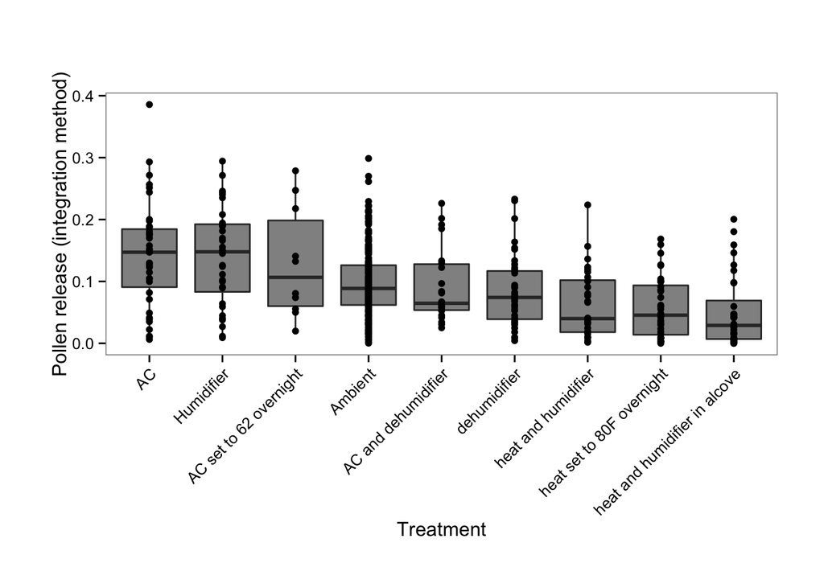

```r
p6.ordered + geom_point() # add points to our plot
```

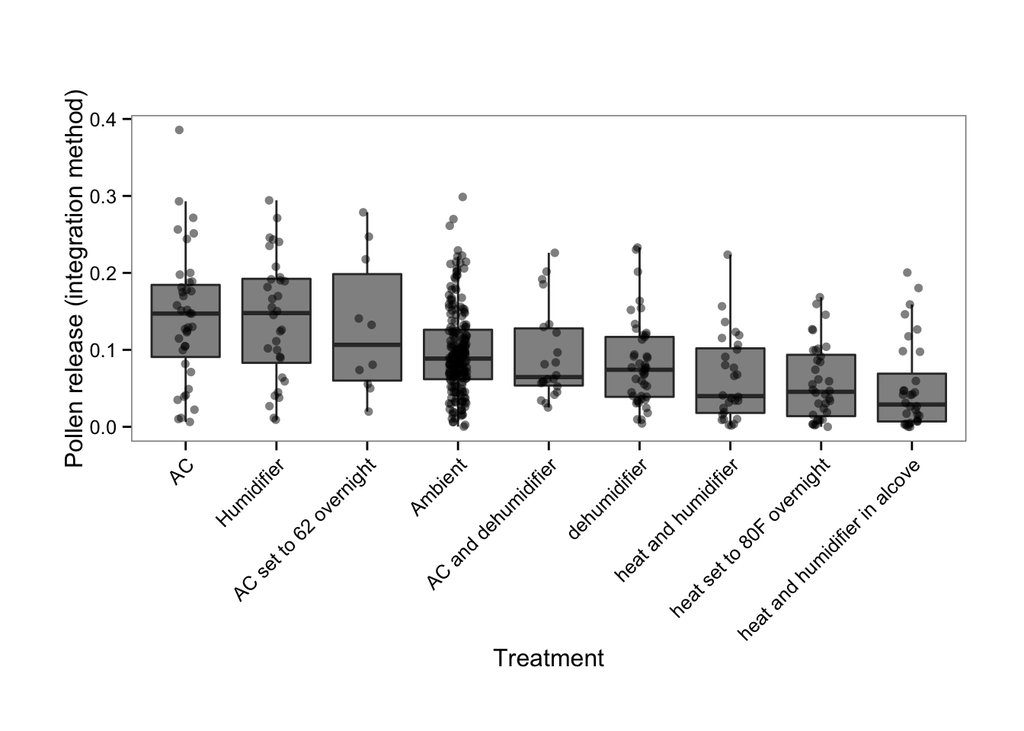

```r
p7 <- p6.ordered + geom_point(position = position_jitter(width = 0.1, height = 0), alpha = 0.5)
p7
```

```r
# save the plot
ggsave("boxpltTrt.pdf", plot = p7,  device = cairo_pdf, width = 89, height = 60, unit = "mm")
file.remove("boxpltTrt.pdf") # remove plot
```

```
## [1] TRUE
```

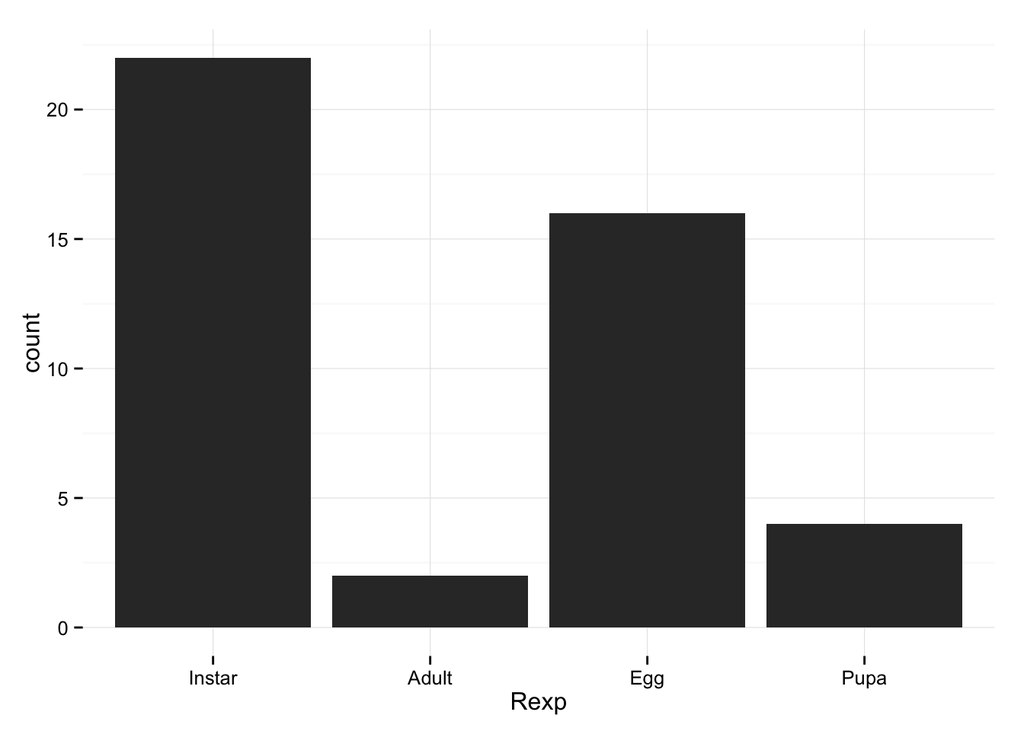

```r
################################  EXAMPLE 3 ################################
# changing the order of the bars in a plot
################################  EXAMPLE 3 ################################
surv <- read.csv("Datasets/survey.csv")

# map values to shorter words
library(plyr)
surv$Rexp <- mapvalues(surv$Rexp, from = as.character(levels(surv$Rexp)), to = c("Instar", "Adult", "Egg", "Pupa"))

ggplot(surv, aes(x = Rexp)) +
     geom_bar()  +
     theme_minimal()
```

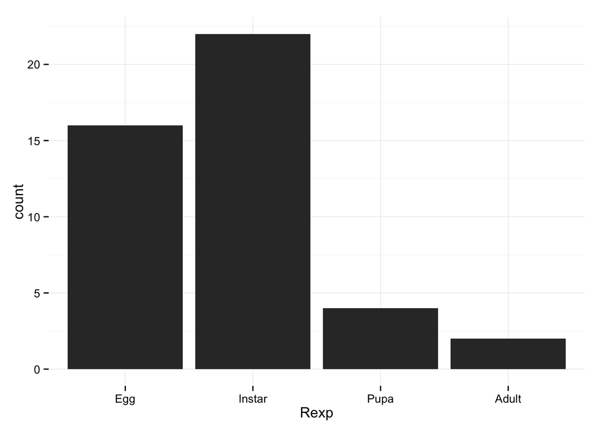

```r
# set new levels
surv$Rexp <- factor(surv$Rexp, levels = c("Egg", "Instar", "Pupa", "Adult"))

# replot
ggplot(surv, aes(x = Rexp)) +
     geom_bar() +
     theme_minimal()
```

Exercises(1, cont’):

#### 1.2 Read in (redo it, if you’ve read it in earlier) the surv.csv file. Use these commands to clean your data:

```
 # makes a new, small data frame that contains only the same levels as the Rexp column
 # drops factor levels with 0 items
 s.sm <- droplevels(surv[surv$BestExp %in% surv$Rexp, ])

 # maps values to one-word, instead of long strings
 library(plyr)
 s.sm$BestExp <- mapvalues(s.sm$BestExp, from = as.character(levels(s.sm$BestExp)), to = c("Instar", "Adult", "Egg", "Pupa"))
```

#### Make a barplot of the s.sm $ BestExp. Change the order of the bars so that they go like this: Egg, Instar, Pupa, Adult

### Adding lines to ggplot

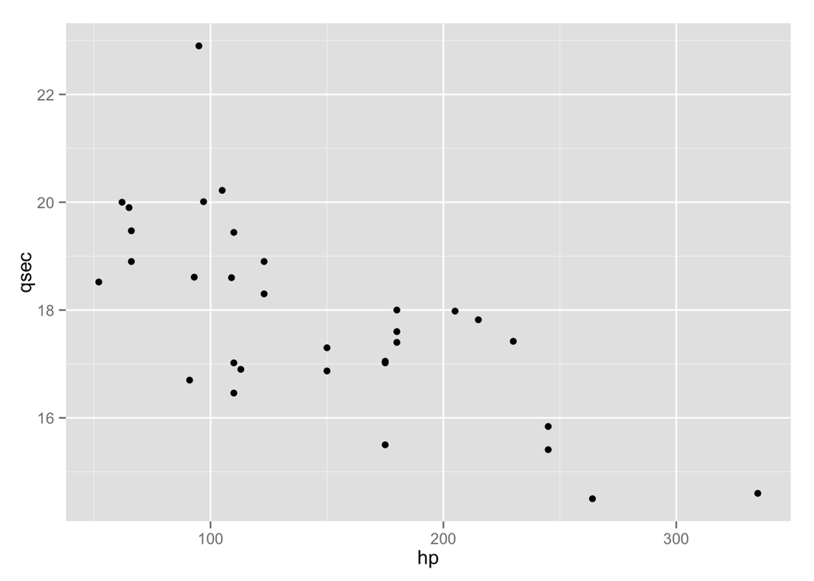

```r
# plot horsepower vs quarter second time
ggplot(crs, aes(x = hp, y = qsec)) +
     geom_point()
```

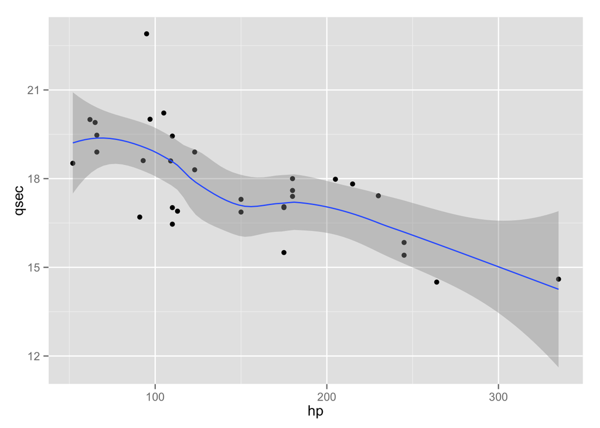

```r
# add a loess (local regression) line
ggplot(crs, aes(x = hp, y = qsec)) +
     geom_point() +
     geom_smooth(method = "loess")
```

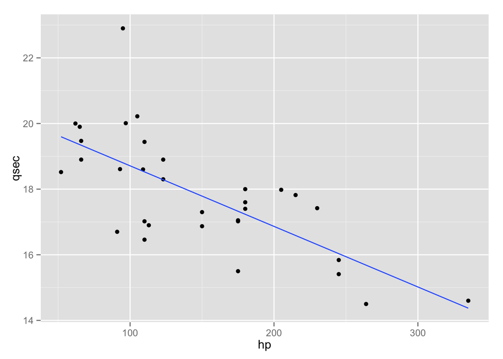

```r
# add least squares line, without standard errors
ggplot(crs, aes(x = hp, y = qsec)) +
     geom_point() +
     geom_smooth(method = "lm", se = FALSE)
```

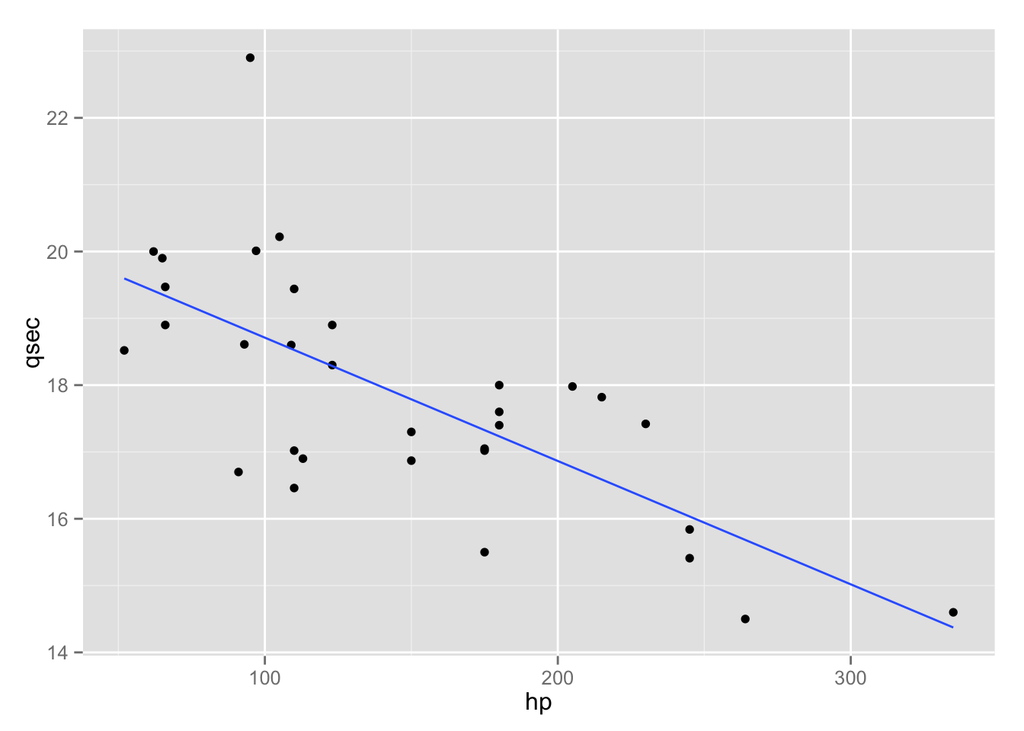

```r
# same thing
ggplot(crs, aes(x = hp, y = qsec)) +
     geom_point() +
     stat_smooth(method = "lm", se = FALSE)
```

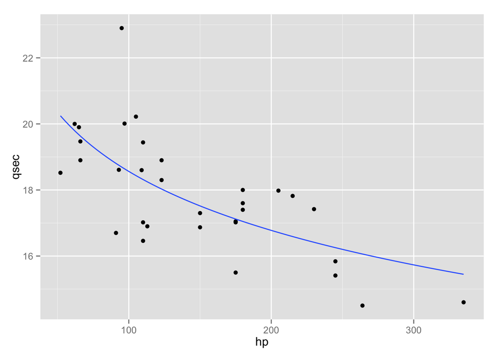

```r
# same thing, specifying formula
ggplot(crs, aes(x = hp, y = qsec)) +
     geom_point() +
     stat_smooth(method = "lm", se = FALSE, formula = y~log(x) )
```

Exercises(1, cont’):

#### 1.3 With the mtcars.txt data, use ggplot to plot x = drat, y = hp. Add a line to your plot. Feel free to change the line color, theme, point color, etc.

# 2. Loops and apply functions

```r
################################  EXAMPLE 1 ################################
# for and while loops
################################  EXAMPLE 1 ################################
# for loops repeat a specific number of times
for(i in 1:10){
     print(i + 100)
}
```

```
## [1] 101
## [1] 102
## [1] 103
## [1] 104
## [1] 105
## [1] 106
## [1] 107
## [1] 108
## [1] 109
## [1] 110
```

```r
# make fake data
df1 <- data.frame(person = c("bob", "sue", "jack", "ann"), number1 = c(4,5,6,1), number2 = c(2,4,6,6))
df1
```

```
##   person number1 number2
## 1    bob       4       2
## 2    sue       5       4
## 3   jack       6       6
## 4    ann       1       6
```

```r
# another for loop
for(ii in df1$person){
    print(rep(ii, times = df1[df1$person == ii, "number1"]))
}
```

```
## [1] "bob" "bob" "bob" "bob"
## [1] "sue" "sue" "sue" "sue" "sue"
## [1] "jack" "jack" "jack" "jack" "jack" "jack"
## [1] "ann"
```

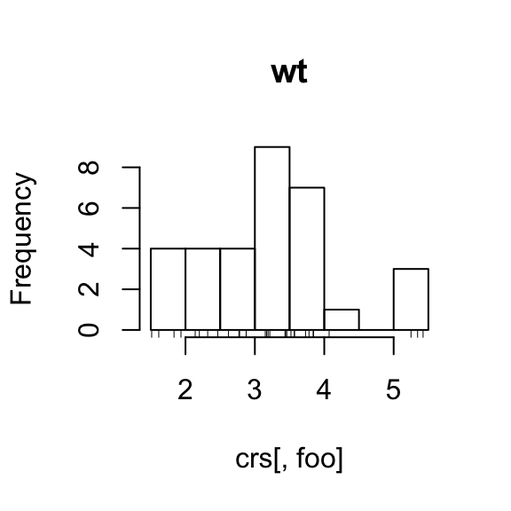

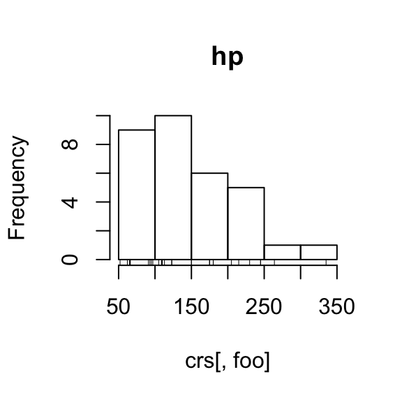

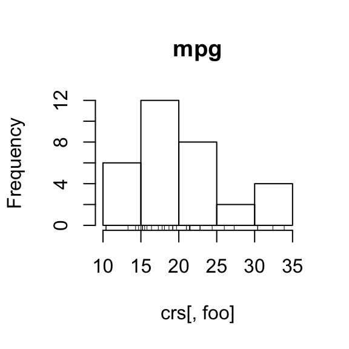

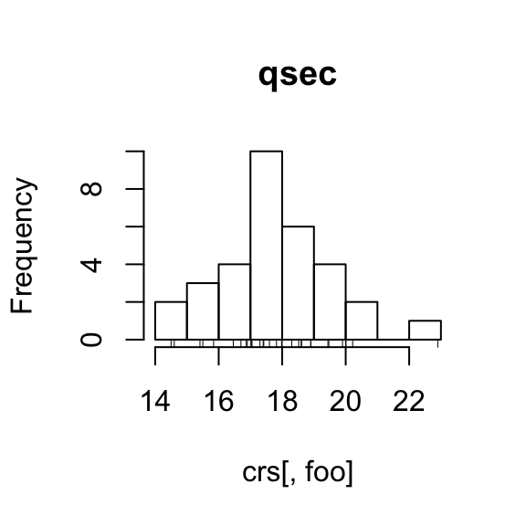

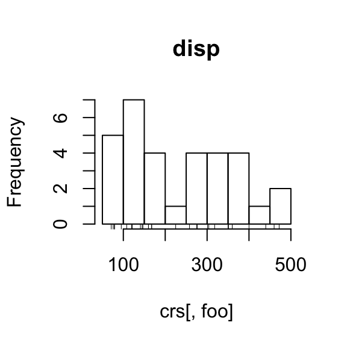

```r
# another for loop to make lots of plots
for(foo in c("wt", "hp", "mpg", "qsec", "disp")){
     hist(crs[ , foo], main = foo)
     rug(crs[ ,foo])
}
```

```r
## while loops repeat until something happens
x <- 1
while(x < 10){
     print(x + 100)
     x <- x + 1
}
```

```
## [1] 101
## [1] 102
## [1] 103
## [1] 104
## [1] 105
## [1] 106
## [1] 107
## [1] 108
## [1] 109
```

Exercises(2):

### 2.1 Write a for loop to print the numbers 1:100

```r
################################  EXAMPLE 2 ################################
# if/else
################################  EXAMPLE 2 ################################

# you can use "if" and "else" inside loops to do different things

for(i in 1:10){
     if(i > 5) print(i + 100)
     else print("hello")
}
```

```
## [1] "hello"
## [1] "hello"
## [1] "hello"
## [1] "hello"
## [1] "hello"
## [1] 106
## [1] 107
## [1] 108
## [1] 109
## [1] 110
```

```r
# same
for(i in 1:10){
     if(i > 5){
         print(i + 100)
     }
     else{
          print("hello")
     }
}
```

```
## [1] "hello"
## [1] "hello"
## [1] "hello"
## [1] "hello"
## [1] "hello"
## [1] 106
## [1] 107
## [1] 108
## [1] 109
## [1] 110
```

```r
# example with data frame
for(nums in 1:length(df1$number1)){
     print(nums)
}
```

```
## [1] 1
## [1] 2
## [1] 3
## [1] 4
```

```r
for(nums in 1:length(df1$number1)){
     print(as.character(df1$person[nums]))
}
```

```
## [1] "bob"
## [1] "sue"
## [1] "jack"
## [1] "ann"
```

```r
for(nums in 1:length(df1$number1)){
     if(as.character(df1$person[nums]) == "sue"){
          print("sue was here")
     }
     else if(as.character(df1$person[nums]) == "bob"){
          print("bob was here")
     }
     else print("ann or jack")
}
```

```
## [1] "bob was here"
## [1] "sue was here"
## [1] "ann or jack"
## [1] "ann or jack"
```

```r
# example of making a new vector
vec1 <- rep(NA, nrow(df1))
for(nums in 1:length(df1$number1)){
     if(as.character(df1$person[nums]) == "sue"){
          vec1[nums] <- ("sue was here")
     }
     else if(as.character(df1$person[nums]) == "bob"){
          vec1[nums] <- ("bob was here")
     }
     else vec1[nums] <- ("ann or jack")
}

vec1
```

```
## [1] "bob was here" "sue was here" "ann or jack"  "ann or jack"
```

Exercises(2, cont’):

### Write a for loop that cycles through the columns of the mtcars.txt dataset (called “crs”, earlier), and makes a histogram, only if the column is numeric.

## Apply functions

```r
################################  EXAMPLE 2 ################################
# apply functions
################################  EXAMPLE 2 ################################

# here's a simple function
x2 <- function(x) x^2

x2(5)
```

```
## [1] 25
```

```r
# here is a function
trimMean <- function(vect) {
     qs <- quantile(vect, probs = c(.10, .90))
     mean(vect[vect > qs[1] & vect < qs[2]])
}

nums <- c(1:100, 1000)
nums2 <- c(50:100, 1500, 1)
nums3 <- c(1,3,5,6,7,7,5,4,34,.76,87,8,8,8,6,5,4.4,4,56,7,7,88,33)

# make a new list, from our numbers
listNums <- list(nums, nums2, nums3)

trimMean(nums)
```

```
## [1] 51
```

```r
trimMean(nums2)
```

```
## [1] 75
```

```r
trimMean(nums3)
```

```
## [1] 9.317647
```

```r
# trimMean(listNums) doesn't work
# trimMean(nums, nums2) #doesn't work
trimMean(c(nums, nums2, nums3)) # doesn't give three different numbers
```

```
## [1] 54.32624
```

```r
# we could write a for loop
listMNS <- numeric(length(listNums))
for(i in 1:length(listNums)){
     listMNS[i] <- trimMean(listNums[[i]])
}
listMNS
```

```
## [1] 51.000000 75.000000  9.317647
```

```r
# or we could use apply
sapply(listNums, FUN = trimMean)
```

```
## [1] 51.000000 75.000000  9.317647
```

```r
## Apply functions are often faster than loops

# this for loop is slow, because we grow the newVec variable on every iteration of the loop
# note: loop isn't needed here, you could just use 1:30000 + 100 to get a new vector.
system.time({
     newVec <- numeric()
     for(ii in 1:30000){
          newVec[ii] <- ii + 100
     }
})
```

```
##    user  system elapsed
##   1.034   0.310   1.346
```

```r
head(newVec)
```

```
## [1] 101 102 103 104 105 106
```

```r
## sapply function (for illustration only....sapply is not necessary here)
# first, we write a function for what we want to happen
x100 <- function(x) x + 100


# apply that function to a vector
system.time({
     newVec.sa <- sapply(X = 1:100000, FUN = x100)
})
```

```
##    user  system elapsed
##   0.058   0.001   0.059
```

```r
head(newVec.sa)
```

```
## [1] 101 102 103 104 105 106
```

```r
## you can speed up a for-loop by pre-allocating space
system.time({

     newVec <- numeric(100000)
     for(ii in 1:100000){
          newVec[ii] <- ii + 100
     }
})
```

```
##    user  system elapsed
##   0.091   0.000   0.093
```

```r
## you can use apply functions on a data frame

# say you want to calculate the trimmed mean (removing the max and min) for several columns in your data frame

tMean <- function(x){
     x <- x[x != min(x, na.rm = TRUE) & x != max(x, na.rm = TRUE)]
     return(mean(x, na.rm=TRUE))
}

tMean(c(1:100, 10000, NA, NA))
```

```
## [1] 51
```

```r
mean(c(1:100, 10000, NA), na.rm =TRUE)
```

```
## [1] 149.0099
```

```r
# you could use a for loop
tms <- numeric()
for(ii in c("temp", "humidity", "int", "slope")){
     tms[ii] <- tMean(flr[, ii])
}

tms
```

```
##         temp     humidity          int        slope
## 25.302283105 55.290476190  0.094796074  0.008759418
```

```r
# or you could use apply
# apply allows you to choose the margin -- I think it converts to a matrix first
apply(X = flr[, c("temp", "humidity", "int", "slope")], MARGIN = 2, FUN = tMean)
```

```
##         temp     humidity          int        slope
## 25.302283105 55.290476190  0.094796074  0.008759418
```

```r
# same thing
sapply(X = flr[, c("temp", "humidity", "int", "slope")], FUN = tMean)
```

```
##         temp     humidity          int        slope
## 25.302283105 55.290476190  0.094796074  0.008759418
```

Exercises(2, cont’):

### 2.3 The following function prints the max or the highest level of a factor.

```r
maxHighF <- function(thing) {
     if(is.numeric(thing)) return(max(thing, na.rm = TRUE))
     else if(is.factor(thing)) return(levels(thing)[length(levels(thing))])
     else return(NA)
}
```

You’ll notice this:

```
 maxHighF(crs$hp) # works
 maxHighF(flr$trt) # works
 maxHighF(flr[, c("trt", "humidity")]) # doesn't work
```

### Apply this function to every column of the flower data frame, using sapply

## Writing your own functions

```r
# functions take in something, do something, then output something

# example 1
printNum.plus5 <- function(num){
     print(num + 5)
}


printNum.plus5(5)
```

```
## [1] 10
```

```r
printNum.plus5(1000)
```

```
## [1] 1005
```

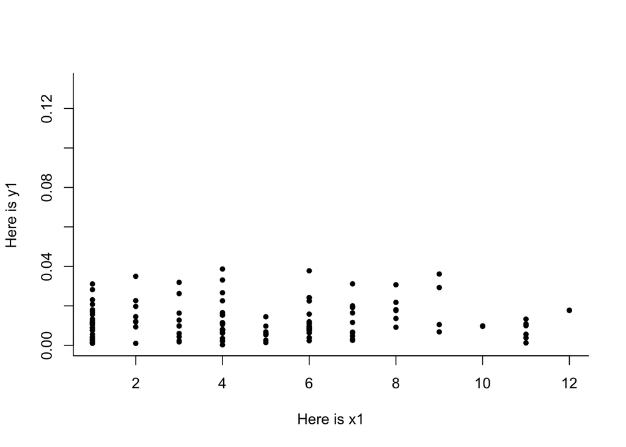

```r
# example 2
plotWithAxisLabels <- function(x1, y1){
     plot(x = x1, y = y1, xlab = "Here is x1", ylab = "Here is y1",
          bty = "l", pch = 20)
}

plotWithAxisLabels(x1 = flr$distance, y1 = flr$slope)
```

```r
# example 3 with sapply
# fake data
df1 <- data.frame(person = c("bob", "sue", "jack", "ann"), number1 = c(4,5,6,1), number2 = c(2,4,6,6))
df1
```

```
##   person number1 number2
## 1    bob       4       2
## 2    sue       5       4
## 3   jack       6       6
## 4    ann       1       6
```

```r
# want to convert to long format
longerizer1 <- function(name){
     rep(name, times = df1[df1$person == name, "number1"])
}

longerizer1("bob")
```

```
## [1] "bob" "bob" "bob" "bob"
```

```r
df1
```

```
##   person number1 number2
## 1    bob       4       2
## 2    sue       5       4
## 3   jack       6       6
## 4    ann       1       6
```

```r
longerizer1("sue")
```

```
## [1] "sue" "sue" "sue" "sue" "sue"
```

```r
longerizer1(c("bob", "sue"))
```

```
## [1] "bob" "bob" "bob" "bob" "sue" "sue" "sue" "sue" "sue"
```

Exercises(3):

### Write a function that takes a column name from the flr dataframe as an argument. If the column is numeric, make a scatterplot of x = that column, y = int, with points colored red. If the column is a factor, then make a boxplot of x = column, y = int, where the boxes are filled with blue.

Extra Practice:

### E.1 Read in the “loblolly.txt” dataset, if you haven’t already. Call it “lob”. Use ggplot() to plot a scatterplot (geom_point()) with x= age, y = height.

### E.2 Using the “lob” dataframe, convert “age” to a factor.

```
 lob$age <- as.factor(lob$age)
```

### E.4 Change the theme from your previous plot to the “classic” theme with theme_classic().